# Distribuciones Multivariadas y Probabilidad

León Berdichevsky Acosta

18 de septiembre de 2018

Un modelo estadístico $F$ es un conjuto de distribuciones (o densidades o funciones de regresión). Un **modelo paramétrico** es un conjunto $F$ que puede ser parametrizado por un número finito de parámetros. Por ejemplo, si suponemos que los datos provienen de una distribución Normal, el modelo es:

$$F=\bigg\{p(x;\mu, \sigma) = \frac{1}{\sigma\sqrt{2\pi}}exp\bigg(-\frac{1}{2\sigma^2}(x-\mu)^2\bigg), \mu \in \mathbb{R}, \sigma>0\bigg\}$$

En general, un modelo paramétrico tiene la forma

$$F=\bigg\{p(x;\theta):\theta \in \Theta \bigg\}$$

donde $\theta$ es un parámetro desconocido (o un vector de parámetros) que puede tomar valores en el espacio paramétrico $\Theta$.

Un modelo **no paramétrico** es un conjunto $F$ que no puede ser parametrizado por un número finito de parámetros.

### Variables aleatorias

Recordemos brevemente algunos conceptos de variables aleatorias.

Una **variable aleatoria** es un mapeo
$$X:\Omega \to \mathbb{R}$$
que asigna un número real $X(\omega)$ a cada elemento $\omega$ en el espacio de resultados.

Ejemplo. Lanzamos una moneda justa dos veces, definimos $X$ como en el número de soles, entonces la variable aleatoria se pueden resumir como:

| $\omega$ | $P(\{\omega\})$ | $X(\omega)$ |
| --- | --- | --- |
| AA | 1/4 | 0 |
| AS | 1/4 | 1 |
| SA | 1/4 | 1 |
| SS | 1/4 | 2 |

La **función de distribución acumulada** es la función $P_X:\mathbb{R}\to[0,1]$ definida como:
$$P_X(x)=P(X\leq x)$$

En el ejemplo:
$$P_X(x) = \left\{
\begin{array}{lr}
0 & x < 0\\
1/4 & 0 \leq x < 1 \\
3/4 & 1 \leq x < 2 \\
1 & x \ge 2
\end{array}
\right.$$

Una variable aleatoria $X$ es **discreta** si toma un número contable de valores $\{x_1,x_2,...\}$. En este caso definimos la función de probabilidad o la función masa de probabilidad de X como $p_X(x)=P(X=x)$.

Notemos que $p_X(x)\geq 0$ para toda $x \in \mathbb{R}$ y $\sum_i p_X(x)=1$. Más aún, la función de distribución acumulada esta relacionada con $p_X$ por
$$P_X(x)=P(X \leq x)= \sum_{x_i\leq x} = \sum_{x_i\leq x}p_{X}(x_i)$$

$$p_X(x) = \left\{
\begin{array}{lr}
1/4 & x = 0 \\
1/2 & x = 1 \\
1/4 & x = 2\\
0 & e.o.c.
\end{array}
\right.$$

Sea $X$ una variable aleatoria con FDA $P_X$. La función de distribución acumulada inversa o **función de cuantiles** se define como:
$$P_X^{-1}(q) = inf\{x:P_X(x)>q\}$$
para $q \in [0,1]$.

Llamamos a $P^{-1}(1/4)$ el primer cuartil, a $P^{-1}(1/2)$ la mediana y $P^{-1}(3/4)$ el tercer cuartil.

### Familias discretas importantes

#### Distribución Uniforme

Decimos que $X$ tiene una distribución uniforme en $\{a,...,b\}$ ($a,b$ enteros) si tiene una función de probailidad dada por:

$$p(x) = \left\{
\begin{array}{lr}
1/n & x \in \{a,...,b\}\\
0 & e.o.c. \\
\end{array}
\right.$$
donde $n = b-a+1$, $E(X) = (a+b)/2, Var(X)=(n^2-1)/12$

#### Distribución Bernoulli

Sea $X$ la variable aleatoria que representa un lanzamiento de moneda, con $P(X=1)=p$ y $P(X=0)=1-p$ para alguna $p\in[0,1].$ Decimos que $X$ tiene una distribución Bernoulli ($X \sim Bernoulli(p)$), y su función de distribución es:

$$p(x) = \left\{
\begin{array}{lr}
p^x(1-p)^{1-x} & x \in \{0,1\}\\
0 & e.o.c. \\
\end{array}
\right.$$

$E(X) = p, Var(X)=p(1-p)$

#### Distribución Binomial

Supongamos que tenemos una moneda que cae en sol con probabilidad $p$, para alguna $p\in[0,1].$ Lanzamos la moneda $n$ veces y sea $X$ el número de soles. Suponemos que los lanzamientos son independientes, entonces la función de distribución es:

$$p(x) = \left\{
\begin{array}{lr}
{n \choose x}p^x(1-p)^{n-x} & x \in \{0,1,...,n\}\\
0 & e.o.c. \\
\end{array}
\right.$$

$E(X) = np, Var(X)=np(1-p)$

Si $X_1 \sim Binomial(n_1, p)$ y $X_2 \sim Binomial(n_2,p)$ entonces $X_1 + X_2 \sim Binomial(n_1+n_2, p)$. En general la distribución binomial describe el comportamiento de una variable $X$ que cuenta número de *éxitos* tal que: 1) el número de observaciones $n$ esta fijo, 2) cada observación es independiente, 3) cada observación representa uno de dos posibles eventos (*éxito* o *fracaso*) y 3) la probabilidad de éxito $p$ es la misma en cada observación.

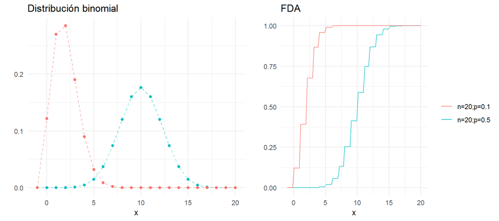

```r
densidades <- ggplot(data.frame(x = -1:20)) +
  geom_point(aes(x = x, y = dbinom(x, size = 20, prob = 0.5), color = "n=20;p=0.5"),
      show.legend = FALSE) +
  geom_path(aes(x = x, y = dbinom(x, size = 20, prob = 0.5), color = "n=20;p=0.5"),
      alpha = 0.6, linetype = "dashed", show.legend = FALSE) +
  geom_point(aes(x = x, y = dbinom(x, size = 20, prob = 0.1), color = "n=20;p=0.1"),
      show.legend = FALSE) +
  geom_path(aes(x = x, y = dbinom(x, size = 20, prob = 0.1), color = "n=20;p=0.1"),
      alpha = 0.6, linetype = "dashed", show.legend = FALSE) +
  labs(color = "", y  = "", title = "Distribución binomial")

dists <- ggplot(data_frame(x = -1:20), aes(x)) +
    stat_function(fun = pbinom, args = list(size = 20, prob = 0.5),
        aes(colour = "n=20;p=0.5"), alpha = 0.8) +
    stat_function(fun = pbinom, args = list(size = 20, prob = 0.1),
        aes(colour = "n=20;p=0.1"), alpha = 0.8) +
    labs(y = "", title = "FDA", color = "")

grid.arrange(densidades, dists, ncol = 2, newpage = FALSE)
```

#### Distribución Poisson

$X$ tienen una distribución Poisson con prámetro $\lambda$ si
$$p(x) = \left\{
\begin{array}{lr}
e^{-\lambda} \frac{\lambda^x}{x!} & x \in \{0,1,...\}\\
0 & e.o.c. \\
\end{array}
\right.$$

$E(X) = \lambda, Var(X)=\lambda$

La distribución Poisson se utiliza con frecuencia para modelar conteos de eventos raros, por ejemplo número de accidentes de tráfico. La distribución Poisson es un caso límite de la distribución binomial cuando el número de casos es muy grande y la probabilidad de éxito $p$ es chica. Si $X_1 \sim Poisson(\lambda_1)$ y $X_2 \sim Poisson(\lambda_2)$ entonces $X_1 + X_2 \sim Poisson(\lambda_1 + \lambda_2)$.

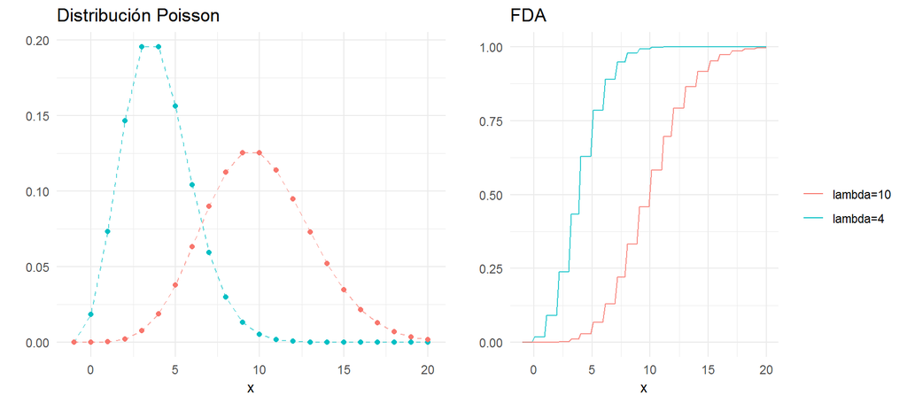

```r
densidades <- ggplot(data.frame(x = -1:20)) +
  geom_point(aes(x = x, y = dpois(x, lambda = 4), color = "lambda=4"), show.legend = FALSE) +
  geom_path(aes(x = x, y = dpois(x, lambda = 4), color = "lambda=4"),
      alpha = 0.6, linetype = "dashed", show.legend = FALSE) +
  geom_point(aes(x = x, y = dpois(x, lambda = 10), color = "lambda=10"), show.legend = FALSE) +
  geom_path(aes(x = x, y = dpois(x, lambda = 10), color = "lambda=10"),
      alpha = 0.6, linetype = "dashed", show.legend = FALSE) +
  labs(color = "", y = "", title = "Distribución Poisson")

dists <- ggplot(data_frame(x = -1:20), aes(x)) +
    stat_function(fun = ppois, args = list(lambda = 4),
        aes(colour = "lambda=4"), alpha = 0.8) +
    stat_function(fun = ppois, args = list(lambda = 10),
        aes(colour = "lambda=10"), alpha = 0.8) +
    labs(y = "", title = "FDA", color = "")

grid.arrange(densidades, dists, ncol = 2, newpage = FALSE)
```

#### Distribución geométrica

$E(X)=1/p, Var(X)=(1-p)/p^2$  
con $k \geq 1$. Podemos pensar en $X$ como el número de lanzamientos necesarios hasta que obtenemos el primer sol en los lanzamientos de una moneda.

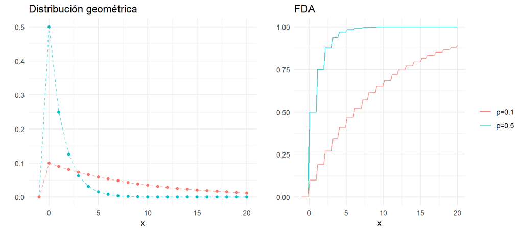

```r
densidades <- ggplot(data.frame(x = -1:20)) +
  geom_point(aes(x = x, y = dgeom(x, p = 0.5), color = "p=0.5"), show.legend = FALSE) +
  geom_path(aes(x = x, y = dgeom(x, p = 0.5), color = "p=0.5"), show.legend = FALSE,
      alpha = 0.6, linetype = "dashed") +
  geom_point(aes(x = x, y = dgeom(x, p = 0.1), color = "p=0.1"), show.legend = FALSE) +
  geom_path(aes(x = x, y = dgeom(x, p = 0.1), color = "p=0.1"),
      show.legend = FALSE, alpha = 0.6, linetype = "dashed") +
  labs(title = "Distribución geométrica", y = "")

dists <- ggplot(data_frame(x = -1:20), aes(x)) +
    stat_function(fun = pgeom, args = list(p = 0.5),
        aes(colour = "p=0.5"), alpha = 0.8) +
    stat_function(fun = pgeom, args = list(p = 0.1),
        aes(colour = "p=0.1"), alpha = 0.8) +
    labs(y = "", title = "FDA", color = "")

grid.arrange(densidades, dists, ncol = 2, newpage = FALSE)
```

### Variables aleatorias continuas

Una variable aleatoria $X$ es **continua** si existe una función $p_x$ tal que $p_X(x) \geq 0$ para toda $x$, $\int_{-\infty}^{\infty}p_X(x)dx=1$ y para toda $a\leq b$,

$$P(a < X < b) = \int_{a}^b p_X(x)dx$$

La función $p_X(x)$ se llama la **función de densidad de probabilidad** (fdp). Tenemos que
$$P_X(x)=\int_{-\infty}^x p_X(t)dt$$
y $p_X(x)=P_X^{\'}(x)$ en todos los puntos $x$ en los que la FDA $P_X$ es diferenciable.

Ejemplo. Supongamos que elegimos un número al azar entre cero y uno, entonces

$$p(x) = \left\{
\begin{array}{lr}
\frac{1}{b-a} & x \in [0, 1]\\
0 & e.o.c. \\
\end{array}
\right.$$
es claro que $p_X(x) \geq 0$ para toda $x$ y $\int_{-\infty}^{\infty}p_X(x)dx=1$, la FDA esta dada por

$$P_X(x) = \left\{
\begin{array}{lr}
0 & x < 0 \\
x & x \in [0,1]\\
1 & x>b \\
\end{array}
\right.$$

Vale la pena notar que en el caso de variables aleatorias continuas $P(X=x)=0$ para toda $x$ y pensar en $p_X(x)$ como $P(X=x)$ solo tiene sentido en el caso discreto.

### Familias Continuas importantes

#### Distribución Uniforme

$X$ tiene una distribución $Uniforme(a,b)$ si

$$p(x) = \left\{
\begin{array}{lr}
\frac{1}{b-a} & x \in [a,b]\\
0 & e.o.c. \\
\end{array}
\right.$$

donde $a < b$. La función de distribución acumualda es

$$P_X(x) = \left\{
\begin{array}{lr}
0 & x < a \\
\frac{x-a}{b-a} & x \in [a,b]\\
1 & x>b \\
\end{array}
\right.$$

$E(X) = (a+b)/2, Var(X)= (b-a)^2/12$

```r
densidades <- ggplot(data_frame(x = c(-5 , 5)), aes(x)) +
    stat_function(fun = dunif, aes(colour = "a=0; b=1"), show.legend = FALSE) +
    stat_function(fun = dunif, args = list(min = -5, max = 5), aes(colour = "a=-5; b=5"), show.legend = FALSE) +
    stat_function(fun = dunif, args = list(min = 0, max = 2), aes(colour = "a=0; b=2"), show.legend = FALSE) +
    labs(y = "", title = "Distribución uniforme", colour = "")

dists <- ggplot(data_frame(x = c(-5 , 5)), aes(x)) +
    stat_function(fun = punif, aes(colour = "a=0; b=1"), show.legend = FALSE) +
    stat_function(fun = punif, args = list(min = -5, max = 5), aes(colour = "a=-5; b=5"), show.legend = FALSE) +
    stat_function(fun = punif, args = list(min = 0, max = 2), aes(colour = "a=0; b=2"), show.legend = FALSE) +
    labs(y = "", title = "FDA")

grid.arrange(densidades, dists, ncol = 3, newpage = FALSE)
```

[output not shown]

#### Distribución Normal

$X$ tiene una distribución normal con parámetros $\mu$ y $\sigma$, denotado $X\sim N(\mu, \sigma^2)$ si

$$p(x) = \frac{1}{\sigma\sqrt{2\pi}}exp\bigg(-\frac{1}{2\sigma^2}(x-\mu)^2\bigg)$$

$E(X)=\mu, Var(X)=\sigma^2$

donde $\mu \in \mathbb{R}$ y $\sigma>0$.

Decimos que $X$ tiene una distribución **Normal estándar** si $\mu=0$ y $\sigma=1$. Una variable aleatoria Normal estándar se denota tradicionalmente por $Z$, su función de densidad de probabilidad por $\phi(z)$ y la función de probabilidad acumulada por $\Phi(z)$.

Algunas porpiedades importantes son:

1. Si $X \sim N(\mu, \sigma^2)$, entonces $Z=(X-\mu)/\sigma \sim N(0,1)$.
2. Si $Z \sim N(0, 1)$ entonces $X = \mu + \sigma Z \sim N(\mu, sigma^2)$.
3. Si $X_i \sim N(\mu_i, \sigma_i^2)$, $i=1,...,n$ independientes, entonces:
   $$\sum_{i=1}^n X_i \sim N(\sum_{i=1}^n \mu_i, \sum_{i=1}^n \sigma_i^2)$$
4. Se sigue de 1 que si $X\sim N(\mu, \sigma^2)$, entonces
   $$P(a<X<b) = P\big(\frac{a-\mu}{\sigma} < Z < \frac{b-\mu}{\sigma}\big)= \Phi\big(\frac{b-\mu}{\sigma}\big) - \Phi\big(\frac{a-\mu}{\sigma}\big)$$

[figure not shown]

```r
densidades <- ggplot(data_frame(x = c(-5 , 5)), aes(x)) +
    stat_function(fun = dnorm, aes(colour = "m=0; s=1"), show.legend = FALSE) +
    stat_function(fun = dnorm, args = list(mean = 1), aes(colour = "m=1; s=1"), show.legend = FALSE) +
    stat_function(fun = dnorm, args = list(sd = 2), aes(colour = "m=1; s=2"), show.legend = FALSE) +
    labs(y = "", title = "Distribución Normal", colour = "")

dists <- ggplot(data_frame(x = c(-5 , 5)), aes(x)) +
    stat_function(fun = pnorm, aes(colour = "m=0; s=1"), show.legend = FALSE) +
    stat_function(fun = pnorm, args = list(mean = 1), aes(colour = "m=1; s=1"), show.legend = FALSE) +
    stat_function(fun = pnorm, args = list(sd = 2), aes(colour = "m=1; s=2"), show.legend = FALSE) +
    labs(y = "", title = "FDA")

cuantiles <- ggplot(data_frame(x = c(0, 1)), aes(x)) +
    stat_function(fun = qnorm, aes(colour = "m=0; s=1")) +
    stat_function(fun = qnorm, args = list(mean = 1), aes(colour = "m=1; s=1")) +
    stat_function(fun = qnorm, args = list(sd = 2), aes(colour = "m=1; s=2")) +
    labs(y = "", title = "Funciones de cuantiles", colour = "")

grid.arrange(densidades, dists, cuantiles, ncol = 3, newpage = FALSE)
```

#### Distribución Exponencial

Una variable aleatoria $X$ tienen distribución Exponencial con parámetro $\beta$, $X \sim Exp(\beta)$ si,

$$p(x) = \left\{
\begin{array}{lr}
\frac{1}{\beta}e^{-x/\beta} & x >0\\
0 & e.o.c. \\
\end{array}
\right.$$

$E(X)=\beta, Var(X)=\beta^2$

donde $\beta > 0$. La distribución exponencial se utiliza para modelar tiempos de espera hasta un evento, por ejemplo modelar el tiempo de vida de un componente electrónico o el tiempo de espera entre llamadas telefónicas.

#### Distribución Gamma

Comencemos definiendo la función Gamma: para $\alpha>0$, $\Gamma(\alpha)=\int_0^{\infty}y^{\alpha-1}e^{-y}dy$, esta función es una extensión de la función factorial, tenemos que si $n$ es un entero positivo, $\Gamma(n)=(n-1)!$.

Ahora, $X$ tienen una distribución Gamma con parámetros $\alpha$, $\beta$, denotado como $X \sim Gamma(\alpha, \beta)$ si
$$p(x) = \left\{
\begin{array}{lr}
\frac{1}{\beta^\alpha \Gamma(\alpha)}x^{\alpha-1}e^{-x/\beta} & x >0\\
0 & e.o.c. \\
\end{array}
\right.$$
$E(X)=\alpha \beta, Var(X)=\alpha \beta^2$

Vale la pena notar que una distribución exponencial es una $Gamma(1, \beta)$. Si $X_i \sim Gamma(\alpha_i, \beta)$ independientes, entonces $\sum_{i=1}^n X_i \sim Gamma(\sum_{i=1}^n \alpha_i, \beta)$.

En la práctica la distribución Gamma se ha usado para modelar el tamaño de las reclamaciones de asegurados, en neurociencia se ha usado para describir la distribución de los intervalos entre los que ocurren picos. Finalmente, la distribución Gamma es muy usada en estadística bayesiana como a priori conjugada para el parámetro de precisión de una distribución Normal.

[figure not shown]

```r
densidades <- ggplot(data_frame(x = c(0 , 12)), aes(x)) +
    stat_function(fun = dgamma, args = list(shape = 1), aes(colour = "a=1;b=1"), show.legend = FALSE) +
    stat_function(fun = dgamma, args = list(scale = 0.5, shape = 2), aes(colour = "a=2;b=0.5"), show.legend = FALSE) +
    stat_function(fun = dgamma, args = list(scale = 3, shape = 4), aes(colour = "a=4,b=3"), show.legend = FALSE) +
    labs(y = "", title = "Distribución Gamma", colour = "")

dists <- ggplot(data_frame(x = c(0 , 12)), aes(x)) +
    stat_function(fun = dgamma, args = list(shape = 1), aes(colour = "a=1;b=1")) +
    stat_function(fun = dgamma, args = list(scale = 0.5, shape = 2), aes(colour = "a=2;b=0.5")) +
    stat_function(fun = dgamma, args = list(scale = 3, shape = 4), aes(colour = "a=4,b=3")) +
    labs(y = "", title = "FDA", color="")

grid.arrange(densidades, dists, ncol = 2, newpage = FALSE)
```

#### Distribución Beta

$X$ tiene una distrinución Beta con parámetros $\alpha > 0$ y $\beta >0$, $X \sim Beta(\alpha, \beta)$ si

$$p(x) = \left\{
\begin{array}{lr}
\frac{\Gamma(\alpha+\beta)}{\Gamma(\alpha)\Gamma(\beta)}x^{\alpha-1}(1-x)^{\beta-1} & 0 < x < 1\\
0 & e.o.c. \\
\end{array}
\right.$$
$E(X)=\alpha/(\alpha+\beta), Var(X)=\alpha \beta /[(\alpha+\beta)^2(\alpha + \beta + 1)]$

La distribución Beta se ha utilizado para describir variables aleatorias limitadas a intervalos de longitud finita, por ejemplo, distribución del tiempo en sistemas de control o administración de proyectos, proporción de minerales en rocas, etc.

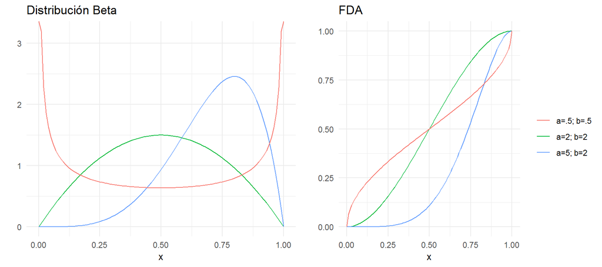

```r
densidades <- ggplot(data_frame(x = c(0 , 1)), aes(x)) +
    stat_function(fun = dbeta, args = list(shape1 = 2, shape2 = 2),
        aes(colour = "a=2; b=2"), show.legend = FALSE) +
    stat_function(fun = dbeta, args = list(shape1 = 5, shape2 = 2),
        aes(colour = "a=5; b=2"), show.legend = FALSE) +
    stat_function(fun = dbeta, args = list(shape1 = .5, shape2 = .5),
        aes(colour = "a=.5; b=.5"), show.legend = FALSE) +
    labs(y = "", title = "Distribución Beta", colour = "")

dists <- ggplot(data_frame(x = c(0 , 1)), aes(x)) +
    stat_function(fun = pbeta, args = list(shape1 = 2, shape2 = 2),
        aes(colour = "a=2; b=2")) +
    stat_function(fun = pbeta, args = list(shape1 = 5, shape2 = 2),
        aes(colour = "a=5; b=2")) +
    stat_function(fun = pbeta, args = list(shape1 = .5, shape2 = .5),
        aes(colour = "a=.5; b=.5")) +
    labs(y = "", title = "FDA", color="")

grid.arrange(densidades, dists, ncol = 2, newpage = FALSE)
```

### Referencias

- The Art of Computer Programming Vol. 2, Donald Knuth.
- Probability, Jim Pitman.
- All of statistics, Larry Wasserman.